# Case Study: How Does a Bike-Share Navigate Speedy Success?

Abel_sebhat

2023-09-14

### Introduction

Welcome to the Cyclistic bike-share analysis case study! You will work for a fictional company, Cyclistic.

### Scenario

Cyclistic, a bike-share company in Chicago. The director of marketing believes the company’s future success depends on maximizing the number of annual memberships. Therefore, your team wants to understand how casual riders and annual members use Cyclistic bikes differently. From these insights, your team will design a new marketing strategy to convert casual riders into annual members. But first, Cyclistic executives must approve your recommendations, so they must be backed up with compelling data insights and professional data visualizations.

### Characters and teams

● Cyclistic: A bike-share program that features more than 5,800 bicycles and 600 docking stations. Cyclistic sets itself apart by also offering reclining bikes, hand tricycles, and cargo bikes, making bike-share more inclusive to people with disabilities and riders who can’t use a standard two-wheeled bike. The majority of riders opt for traditional bikes; about 8% of riders use the assistive options. Cyclistic users are more likely to ride for leisure, but about 30% use them to commute to work each day.

● Lily Moreno: The director of marketing and your manager. Moreno is responsible for the development of campaigns and initiatives to promote the bike-share program. These may include email, social media, and other channels.

● Cyclistic marketing analytics team: A team of data analysts who are responsible for collecting, analyzing, and reporting data that helps guide Cyclistic marketing strategy. You joined this team six months ago and have been busy learning about Cyclistic’s mission and business goals — as well as how you, as a junior data analyst, can help Cyclistic achieve them.

● Cyclistic executive team: The notoriously detail-oriented executive team will decide whether to approve the recommended marketing program.

### About the company

In 2016, Cyclistic launched a successful bike-share offering. Since then, the program has grown to a fleet of 5,824 bicycles that are geotracked and locked into a network of 692 stations across Chicago. The bikes can be unlocked from one station and returned to any other station in the system anytime.

Until now, Cyclistic’s marketing strategy relied on building general awareness and appealing to broad consumer segments. One approach that helped make these things possible was the flexibility of its pricing plans: single-ride passes, full-day passes, and annual memberships. Customers who purchase single-ride or full-day passes are referred to as customer riders. Customers who purchase annual memberships are Cyclistic subscriber.

Cyclistic’s finance analysts have concluded that subscribers are much more profitable than customer riders. Although the pricing flexibility helps Cyclistic attract more customers, Moreno believes that maximizing the number of annual members will be key to future growth. Rather than creating a marketing campaign that targets all-new customers, Moreno believes there is a very good chance to convert customer riders into subscribers. She notes that customer riders are already aware of the Cyclistic program and have chosen Cyclistic for their mobility needs.

Moreno has set a clear goal: Design marketing strategies aimed at converting customer riders into subscriber. In order to do that, however, the marketing analyst team needs to better understand how subscribers and customer riders differ, why customer riders would buy a membership, and how digital media could affect their marketing tactics. Moreno and her team are interested in analyzing the Cyclistic historical bike trip data to identify trends.

### Business task

Three questions will guide the future marketing program:

1. How do subscribers and customer riders use Cyclistic bikes differently?
2. Why would customer riders buy Cyclistic annual memberships?
3. How can Cyclistic use digital media to influence customer riders to become members?

Moreno has assigned you the first question to answer: How do annual members and customer riders use Cyclistic bikes differently?

### Data Sources

For the purposes of this case study,the data sets are appropriate and will enable you to answer the business questions. The data has been made available by Motivate International Inc. under this [license](https://ride.divvybikes.com/data-license-agreement). This is public data that you can use to explore how different customer types are using Cyclistic bikes. But note that data-privacy issues prohibit you from using riders’ personally identifiable information. This means that you won’t be able to connect pass purchases to credit card numbers to determine if casual riders live in the Cyclistic service area or if they have purchased multiple single passes.

Main source of data provided by [cyclistic company](https://divvy-tripdata.s3.amazonaws.com/index.html)

### Loading pacakges

```r
library(tidyverse)
library(here)
library(skimr)
library(janitor)
```

### Importing data from desktop

```r
Divvy_Trips_2019_Q1 <- read_csv("C:/Users/abela/OneDrive/Desktop/cyclistic case study/Divvy_Trips_2019_Q1.csv")
Divvy_Trips_2019_Q2 <- read_csv("C:/Users/abela/OneDrive/Desktop/cyclistic case study/Divvy_Trips_2019_Q2.csv")
Divvy_Trips_2019_Q3 <- read_csv("C:/Users/abela/OneDrive/Desktop/cyclistic case study/Divvy_Trips_2019_Q3.csv")
Divvy_Trips_2019_Q4 <- read_csv("C:/Users/abela/OneDrive/Desktop/cyclistic case study/Divvy_Trips_2019_Q4.csv")
```

### Checking the data frame

```r
colnames(Divvy_Trips_2019_Q1)
```

```
##  [1] "trip_id"           "start_time"        "end_time"
##  [4] "bikeid"            "tripduration"      "from_station_id"
##  [7] "from_station_name" "to_station_id"     "to_station_name"
## [10] "usertype"          "gender"            "birthyear"
```

```r
colnames(Divvy_Trips_2019_Q2)
```

```
##  [1] "01 - Rental Details Rental ID"
##  [2] "01 - Rental Details Local Start Time"
##  [3] "01 - Rental Details Local End Time"
##  [4] "01 - Rental Details Bike ID"
##  [5] "01 - Rental Details Duration In Seconds Uncapped"
##  [6] "03 - Rental Start Station ID"
##  [7] "03 - Rental Start Station Name"
##  [8] "02 - Rental End Station ID"
##  [9] "02 - Rental End Station Name"
## [10] "User Type"
## [11] "Member Gender"
## [12] "05 - Member Details Member Birthday Year"
```

```r
colnames(Divvy_Trips_2019_Q3)
```

```
##  [1] "trip_id"           "start_time"        "end_time"
##  [4] "bikeid"            "tripduration"      "from_station_id"
##  [7] "from_station_name" "to_station_id"     "to_station_name"
## [10] "usertype"          "gender"            "birthyear"
```

```r
colnames(Divvy_Trips_2019_Q4)
```

```
##  [1] "trip_id"           "start_time"        "end_time"
##  [4] "bikeid"            "tripduration"      "from_station_id"
##  [7] "from_station_name" "to_station_id"     "to_station_name"
## [10] "usertype"          "gender"            "birthyear"
```

```r
head(Divvy_Trips_2019_Q1)
```

```
## # A tibble: 6 × 12
##    trip_id start_time          end_time            bikeid tripduration
##      <dbl> <dttm>              <dttm>               <dbl>        <dbl>
## 1 21742443 2019-01-01 00:04:37 2019-01-01 00:11:07   2167          390
## 2 21742444 2019-01-01 00:08:13 2019-01-01 00:15:34   4386          441
## 3 21742445 2019-01-01 00:13:23 2019-01-01 00:27:12   1524          829
## 4 21742446 2019-01-01 00:13:45 2019-01-01 00:43:28    252         1783
## 5 21742447 2019-01-01 00:14:52 2019-01-01 00:20:56   1170          364
## 6 21742448 2019-01-01 00:15:33 2019-01-01 00:19:09   2437          216
## # ℹ 7 more variables: from_station_id <dbl>, from_station_name <chr>,
## #   to_station_id <dbl>, to_station_name <chr>, usertype <chr>, gender <chr>,
## #   birthyear <dbl>
```

```r
head(Divvy_Trips_2019_Q2)
```

```
## # A tibble: 6 × 12
##   `01 - Rental Details Rental ID` 01 - Rental Details L…¹ 01 - Rental Details …²
##                             <dbl> <dttm>                  <dttm>
## 1                        22178529 2019-04-01 00:02:22     2019-04-01 00:09:48
## 2                        22178530 2019-04-01 00:03:02     2019-04-01 00:20:30
## 3                        22178531 2019-04-01 00:11:07     2019-04-01 00:15:19
## 4                        22178532 2019-04-01 00:13:01     2019-04-01 00:18:58
## 5                        22178533 2019-04-01 00:19:26     2019-04-01 00:36:13
## 6                        22178534 2019-04-01 00:19:39     2019-04-01 00:23:56
## # ℹ abbreviated names: ¹`01 - Rental Details Local Start Time`,
## #   ²`01 - Rental Details Local End Time`
## # ℹ 9 more variables: `01 - Rental Details Bike ID` <dbl>,
## #   `01 - Rental Details Duration In Seconds Uncapped` <dbl>,
## #   `03 - Rental Start Station ID` <dbl>,
## #   `03 - Rental Start Station Name` <chr>, `02 - Rental End Station ID` <dbl>,
## #   `02 - Rental End Station Name` <chr>, `User Type` <chr>, …
```

```r
head(Divvy_Trips_2019_Q3)
```

```
## # A tibble: 6 × 12
##    trip_id start_time          end_time            bikeid tripduration
##      <dbl> <dttm>              <dttm>               <dbl>        <dbl>
## 1 23479388 2019-07-01 00:00:27 2019-07-01 00:20:41   3591         1214
## 2 23479389 2019-07-01 00:01:16 2019-07-01 00:18:44   5353         1048
## 3 23479390 2019-07-01 00:01:48 2019-07-01 00:27:42   6180         1554
## 4 23479391 2019-07-01 00:02:07 2019-07-01 00:27:10   5540         1503
## 5 23479392 2019-07-01 00:02:13 2019-07-01 00:22:26   6014         1213
## 6 23479393 2019-07-01 00:02:21 2019-07-01 00:07:31   4941          310
## # ℹ 7 more variables: from_station_id <dbl>, from_station_name <chr>,
## #   to_station_id <dbl>, to_station_name <chr>, usertype <chr>, gender <chr>,
## #   birthyear <dbl>
```

```r
head(Divvy_Trips_2019_Q4)
```

```
## # A tibble: 6 × 12
##    trip_id start_time          end_time            bikeid tripduration
##      <dbl> <dttm>              <dttm>               <dbl>        <dbl>
## 1 25223640 2019-10-01 00:01:39 2019-10-01 00:17:20   2215          940
## 2 25223641 2019-10-01 00:02:16 2019-10-01 00:06:34   6328          258
## 3 25223642 2019-10-01 00:04:32 2019-10-01 00:18:43   3003          850
## 4 25223643 2019-10-01 00:04:32 2019-10-01 00:43:43   3275         2350
## 5 25223644 2019-10-01 00:04:34 2019-10-01 00:35:42   5294         1867
## 6 25223645 2019-10-01 00:04:38 2019-10-01 00:10:51   1891          373
## # ℹ 7 more variables: from_station_id <dbl>, from_station_name <chr>,
## #   to_station_id <dbl>, to_station_name <chr>, usertype <chr>, gender <chr>,
## #   birthyear <dbl>
```

### Changing column names

To make the data frame same i will change Divvy_Trips_2019_Q2 column names.

```r
colnames(Divvy_Trips_2019_Q2) <- c("trip_id", "start_time", "end_time", "bikeid", "tripduration", "from_station_id", "from_station_name", "to_station_id", "to_station_name", "usertype", "gender", "birthyear")
colnames(Divvy_Trips_2019_Q2)
```

```
##  [1] "trip_id"           "start_time"        "end_time"
##  [4] "bikeid"            "tripduration"      "from_station_id"
##  [7] "from_station_name" "to_station_id"     "to_station_name"
## [10] "usertype"          "gender"            "birthyear"
```

### Merging the four data frames into one

```r
Divvy_Trips_2019 = bind_rows(Divvy_Trips_2019_Q1, Divvy_Trips_2019_Q2, Divvy_Trips_2019_Q3, Divvy_Trips_2019_Q4)
View(Divvy_Trips_2019)
```

```r
clean_names(Divvy_Trips_2019)
```

```
## # A tibble: 3,818,004 × 12
##     trip_id start_time          end_time            bikeid tripduration
##       <dbl> <dttm>              <dttm>               <dbl>        <dbl>
##  1 21742443 2019-01-01 00:04:37 2019-01-01 00:11:07   2167          390
##  2 21742444 2019-01-01 00:08:13 2019-01-01 00:15:34   4386          441
##  3 21742445 2019-01-01 00:13:23 2019-01-01 00:27:12   1524          829
##  4 21742446 2019-01-01 00:13:45 2019-01-01 00:43:28    252         1783
##  5 21742447 2019-01-01 00:14:52 2019-01-01 00:20:56   1170          364
##  6 21742448 2019-01-01 00:15:33 2019-01-01 00:19:09   2437          216
##  7 21742449 2019-01-01 00:16:06 2019-01-01 00:19:03   2708          177
##  8 21742450 2019-01-01 00:18:41 2019-01-01 00:20:21   2796          100
##  9 21742451 2019-01-01 00:18:43 2019-01-01 00:47:30   6205         1727
## 10 21742452 2019-01-01 00:19:18 2019-01-01 00:24:54   3939          336
## # ℹ 3,817,994 more rows
## # ℹ 7 more variables: from_station_id <dbl>, from_station_name <chr>,
## #   to_station_id <dbl>, to_station_name <chr>, usertype <chr>, gender <chr>,
## #   birthyear <dbl>
```

### inspect the new table

```r
colnames(Divvy_Trips_2019)
```

```
##  [1] "trip_id"           "start_time"        "end_time"
##  [4] "bikeid"            "tripduration"      "from_station_id"
##  [7] "from_station_name" "to_station_id"     "to_station_name"
## [10] "usertype"          "gender"            "birthyear"
```

```r
summary(Divvy_Trips_2019)
```

```
##     trip_id           start_time
##  Min.   :21742443   Min.   :2019-01-01 00:04:37.00
##  1st Qu.:22873787   1st Qu.:2019-05-29 15:49:26.50
##  Median :23962320   Median :2019-07-25 17:50:54.00
##  Mean   :23915629   Mean   :2019-07-19 21:47:37.11
##  3rd Qu.:24963703   3rd Qu.:2019-09-15 06:48:05.75
##  Max.   :25962904   Max.   :2019-12-31 23:57:17.00
##
##     end_time                          bikeid      tripduration
##  Min.   :2019-01-01 00:11:07.00   Min.   :   1   Min.   :      61
##  1st Qu.:2019-05-29 16:09:28.25   1st Qu.:1727   1st Qu.:     411
##  Median :2019-07-25 18:12:23.00   Median :3451   Median :     709
##  Mean   :2019-07-19 22:11:47.56   Mean   :3380   Mean   :    1450
##  3rd Qu.:2019-09-15 08:30:13.25   3rd Qu.:5046   3rd Qu.:    1283
##  Max.   :2020-01-21 13:54:35.00   Max.   :6946   Max.   :10628400
##
##  from_station_id from_station_name  to_station_id   to_station_name
##  Min.   :  1.0   Length:3818004     Min.   :  1.0   Length:3818004
##  1st Qu.: 77.0   Class :character   1st Qu.: 77.0   Class :character
##  Median :174.0   Mode  :character   Median :174.0   Mode  :character
##  Mean   :201.7                      Mean   :202.6
##  3rd Qu.:289.0                      3rd Qu.:291.0
##  Max.   :673.0                      Max.   :673.0
##
##    usertype            gender            birthyear
##  Length:3818004     Length:3818004     Min.   :1759
##  Class :character   Class :character   1st Qu.:1979
##  Mode  :character   Mode  :character   Median :1987
##                                        Mean   :1984
##                                        3rd Qu.:1992
##                                        Max.   :2014
##                                        NA's   :538751
```

```r
head(Divvy_Trips_2019)
```

```
## # A tibble: 6 × 12
##    trip_id start_time          end_time            bikeid tripduration
##      <dbl> <dttm>              <dttm>               <dbl>        <dbl>
## 1 21742443 2019-01-01 00:04:37 2019-01-01 00:11:07   2167          390
## 2 21742444 2019-01-01 00:08:13 2019-01-01 00:15:34   4386          441
## 3 21742445 2019-01-01 00:13:23 2019-01-01 00:27:12   1524          829
## 4 21742446 2019-01-01 00:13:45 2019-01-01 00:43:28    252         1783
## 5 21742447 2019-01-01 00:14:52 2019-01-01 00:20:56   1170          364
## 6 21742448 2019-01-01 00:15:33 2019-01-01 00:19:09   2437          216
## # ℹ 7 more variables: from_station_id <dbl>, from_station_name <chr>,
## #   to_station_id <dbl>, to_station_name <chr>, usertype <chr>, gender <chr>,
## #   birthyear <dbl>
```

### Checking for NA values

```r
sum(is.na(Divvy_Trips_2019$trip_id))
```

```
## [1] 0
```

```r
sum(is.na(Divvy_Trips_2019$start_time))
```

```
## [1] 0
```

```r
sum(is.na(Divvy_Trips_2019$end_time))
```

```
## [1] 0
```

```r
sum(is.na(Divvy_Trips_2019$bikeid))
```

```
## [1] 0
```

```r
sum(is.na(Divvy_Trips_2019$tripduration))
```

```
## [1] 0
```

```r
sum(is.na(Divvy_Trips_2019$from_station_id))
```

```
## [1] 0
```

```r
sum(is.na(Divvy_Trips_2019$from_station_name))
```

```
## [1] 0
```

```r
sum(is.na(Divvy_Trips_2019$to_station_id))
```

```
## [1] 0
```

```r
sum(is.na(Divvy_Trips_2019$to_station_name))
```

```
## [1] 0
```

```r
sum(is.na(Divvy_Trips_2019$usertype))
```

```
## [1] 0
```

```r
sum(is.na(Divvy_Trips_2019$gender))
```

```
## [1] 559206
```

```r
sum(is.na(Divvy_Trips_2019$birthyear))
```

```
## [1] 538751
```

Only two columns have na values.Gender have 559206 na values and birthyear have 538751 na values. This two columns will not affect the analysis. so i didn’t remove them. They may be “optional” to to users to include those information.

### Adding four new columns

Columns for date, day, months and day_of_week. First create date column to create the others columns from the date column.

```r
Divvy_Trips_2019$date<- as.Date(Divvy_Trips_2019$start_time)
Divvy_Trips_2019$day= format(as.Date(Divvy_Trips_2019$date), "%d")
Divvy_Trips_2019$month= format(as.Date(Divvy_Trips_2019$date), "%b")
Divvy_Trips_2019$day_of_week= format(as.Date(Divvy_Trips_2019$date), "%A")
```

### Adding rides starting hours column

```r
Divvy_Trips_2019<- Divvy_Trips_2019%>%
  mutate(hour= hour(start_time))
```

### changing trip duration in to minutes

```r
Divvy_Trips_2019 <- Divvy_Trips_2019 %>%
  mutate(tripduration = difftime(end_time, start_time, units = "mins"))
Divvy_Trips_2019$tripduration <- round(Divvy_Trips_2019$tripduration, digits = 1)
```

### Removing negative trip duration

```r
Divvy_Trips_2019 <- subset(Divvy_Trips_2019, tripduration >=0)
```

Thirteen rows with negative trip duration removed.

### order week days and months

```r
Divvy_Trips_2019$day_of_week<- ordered(Divvy_Trips_2019$day_of_week,levels=c("Sunday","Monday","Tuesday","Wednesday","Thursday","Friday","Saturday"))
Divvy_Trips_2019$month<- ordered(Divvy_Trips_2019$month, levels= c("Jan", "Feb", "Mar", "Apr", "May", "Jun", "Jul", "Aug", "Sep", "Oct", "Nov", "Dec"))
```

## Data analysis

### Total number of rides in days of the weeks and months by user type

```r
table(Divvy_Trips_2019$usertype, Divvy_Trips_2019$day_of_week)
```

```
##
##              Sunday Monday Tuesday Wednesday Thursday Friday Saturday
##   Customer   170173 101489   88655     89745   101372 121141   208056
##   Subscriber 256234 458780  497025    494277   486915 456966   287163
```

```r
table(Divvy_Trips_2019$usertype, Divvy_Trips_2019$month)
```

```
##
##                 Jan    Feb    Mar    Apr    May    Jun    Jul    Aug    Sep
##   Customer     4602   2638  15923  47744  81624 130218 175632 186889 129173
##   Subscriber  98670  93548 149688 217566 285834 345177 381683 403295 364046
##
##                 Oct    Nov    Dec
##   Customer    71035  18723  16430
##   Subscriber 300751 158440 138662
```

The above table shows that cyclistic have more subscriber user type using bikes on every day of the weeks and months.

### comparing subscriber and customers

```r
aggregate(Divvy_Trips_2019$tripduration ~ Divvy_Trips_2019$usertype, FUN = mean)
```

```
##   Divvy_Trips_2019$usertype Divvy_Trips_2019$tripduration
## 1                  Customer                 57.01797 mins
## 2                Subscriber                 14.32786 mins
```

```r
aggregate(Divvy_Trips_2019$tripduration ~ Divvy_Trips_2019$usertype, FUN = median)
```

```
##   Divvy_Trips_2019$usertype Divvy_Trips_2019$tripduration
## 1                  Customer                     25.8 mins
## 2                Subscriber                      9.8 mins
```

```r
aggregate(Divvy_Trips_2019$tripduration ~ Divvy_Trips_2019$usertype, FUN = max)
```

```
##   Divvy_Trips_2019$usertype Divvy_Trips_2019$tripduration
## 1                  Customer                 177200.4 mins
## 2                Subscriber                 150943.9 mins
```

```r
aggregate(Divvy_Trips_2019$tripduration ~ Divvy_Trips_2019$usertype, FUN = min)
```

```
##   Divvy_Trips_2019$usertype Divvy_Trips_2019$tripduration
## 1                  Customer                        1 mins
## 2                Subscriber                        1 mins
```

### Average ride time by each day for subscriber and customer

```r
aggregate(Divvy_Trips_2019$tripduration ~ Divvy_Trips_2019$usertype + Divvy_Trips_2019$day_of_week, FUN = mean)
```

```
##    Divvy_Trips_2019$usertype Divvy_Trips_2019$day_of_week
## 1                   Customer                       Sunday
## 2                 Subscriber                       Sunday
## 3                   Customer                       Monday
## 4                 Subscriber                       Monday
## 5                   Customer                      Tuesday
## 6                 Subscriber                      Tuesday
## 7                   Customer                    Wednesday
## 8                 Subscriber                    Wednesday
## 9                   Customer                     Thursday
## 10                Subscriber                     Thursday
## 11                  Customer                       Friday
## 12                Subscriber                       Friday
## 13                  Customer                     Saturday
## 14                Subscriber                     Saturday
##    Divvy_Trips_2019$tripduration
## 1                  56.18506 mins
## 2                  15.40302 mins
## 3                  54.49986 mins
## 4                  14.24942 mins
## 5                  57.41343 mins
## 6                  14.15263 mins
## 7                  60.33379 mins
## 8                  13.80987 mins
## 9                  59.95111 mins
## 10                 13.77988 mins
## 11                 60.17561 mins
## 12                 13.89753 mins
## 13                 54.06108 mins
## 14                 16.30269 mins
```

```r
aggregate(Divvy_Trips_2019$tripduration ~ Divvy_Trips_2019$usertype + Divvy_Trips_2019$month, FUN = mean)
```

```
##    Divvy_Trips_2019$usertype Divvy_Trips_2019$month
## 1                   Customer                    Jan
## 2                 Subscriber                    Jan
## 3                   Customer                    Feb
## 4                 Subscriber                    Feb
## 5                   Customer                    Mar
## 6                 Subscriber                    Mar
## 7                   Customer                    Apr
## 8                 Subscriber                    Apr
## 9                   Customer                    May
## 10                Subscriber                    May
## 11                  Customer                    Jun
## 12                Subscriber                    Jun
## 13                  Customer                    Jul
## 14                Subscriber                    Jul
```

[output cut: 35 more lines]

Based on days of the week the trip duration for user types, customer use cyclist bikes on average 55-60 minutes seven days. Slightly difference each days. subscribers use cyclist bikes weekdays on average 13-15 minutes each days. Based on months the trip duration for each user types, customer use cyclist bikes on average jan and jun are the lowest around 46minutes. Feb is the highest(more than 50% of the other months) on average 145minutes. Aug and Nov are the second highest around 67minutes. The other(mar, apr, may, jul, sep, oct and dec) on average 50-60minutes. Subscriber uses of the cyclist on average by months are around 11-16 minutes.

### Top three starting stations by user type

```r
Divvy_Trips_2019 %>%
  group_by(from_station_id, from_station_name, usertype)%>%
  count(from_station_id) %>%
  arrange(-n)
```

```
## # A tibble: 1,276 × 4
## # Groups:   from_station_id, from_station_name, usertype [1,276]
##    from_station_id from_station_name            usertype       n
##              <dbl> <chr>                        <chr>      <int>
##  1              35 Streeter Dr & Grand Ave      Customer   53104
##  2             192 Canal St & Adams St          Subscriber 50575
##  3              77 Clinton St & Madison St      Subscriber 45990
##  4              91 Clinton St & Washington Blvd Subscriber 45378
##  5              76 Lake Shore Dr & Monroe St    Customer   39238
##  6             195 Columbus Dr & Randolph St    Subscriber 31370
##  7             287 Franklin St & Monroe St      Subscriber 30832
##  8             133 Kingsbury St & Kinzie St     Subscriber 30654
##  9              81 Daley Center Plaza           Subscriber 30423
## 10             174 Canal St & Madison St        Subscriber 27138
## # ℹ 1,266 more rows
```

The top three starting stations by user types are station_id 35, 192, 77 station_names “streeter Dr & Grand Ave”, “Canal St & Adams St”, “Clinton St & Madison St” by user type “customer”, “subscriber”, “subscriber” with total starting of 53104, 50575, 45990 respectively. The top three starting stations for customers are “streeter Dr & Grand Ave”, “Lake Shore Dr & Monroe St” and “Millennium Park” with total ride starting of 53104, 39238 and 21749 respectively.

### Top three startings stations

```r
Divvy_Trips_2019 %>%
  group_by(from_station_id, from_station_name)%>%
  count(from_station_id) %>%
  arrange(-n)
```

```
## # A tibble: 640 × 3
## # Groups:   from_station_id, from_station_name [640]
##    from_station_id from_station_name                n
##              <dbl> <chr>                        <int>
##  1              35 Streeter Dr & Grand Ave      67983
##  2             192 Canal St & Adams St          54389
##  3              77 Clinton St & Madison St      49908
##  4              76 Lake Shore Dr & Monroe St    49804
##  5              91 Clinton St & Washington Blvd 48153
##  6             195 Columbus Dr & Randolph St    39192
##  7              43 Michigan Ave & Washington St 37696
##  8              85 Michigan Ave & Oak St        35449
##  9             268 Lake Shore Dr & North Blvd   34472
## 10             287 Franklin St & Monroe St      34297
## # ℹ 630 more rows
```

The top three starting stations are station id 35, 192, 77 with number of rides start by both user types 67983, 54389, 49908 respectively. The above three stations are most riders start using cyclistic bikes.

### Top three ending ride stations by user type

```r
Divvy_Trips_2019 %>%
  group_by(to_station_id, to_station_name, usertype)%>%
  count(to_station_id)%>%
arrange(-n)
```

```
## # A tibble: 1,280 × 4
## # Groups:   to_station_id, to_station_name, usertype [1,280]
##    to_station_id to_station_name              usertype       n
##            <dbl> <chr>                        <chr>      <int>
##  1            35 Streeter Dr & Grand Ave      Customer   67585
##  2            91 Clinton St & Washington Blvd Subscriber 48193
##  3           192 Canal St & Adams St          Subscriber 47330
##  4            77 Clinton St & Madison St      Subscriber 44307
##  5            76 Lake Shore Dr & Monroe St    Customer   30673
##  6            81 Daley Center Plaza           Subscriber 30631
##  7           133 Kingsbury St & Kinzie St     Subscriber 30212
##  8            43 Michigan Ave & Washington St Subscriber 27934
##  9           287 Franklin St & Monroe St      Subscriber 26763
## 10           174 Canal St & Madison St        Subscriber 26339
## # ℹ 1,270 more rows
```

The top three ending stations by user types are station id 35, 91 & 192 station name “Streeter Dr & Grand Ave” , “Clinton St & Washington Blvd” and “Canal St & Adams St” user type customer, subscriber with total ending ride numbers 67585, 48193 & 47330 respectively. The top three ending stations by customer user types are “Streeter Dr & Grand Ave”, “Lake Shore Dr & Monroe St” and “Millennium Park” with ending ride number 67585, 30673 and 25215 respectively.

### Top three ending stations

```r
Divvy_Trips_2019 %>%
  group_by(to_station_id, to_station_name)%>%
  count(to_station_id)%>%
arrange(-n)
```

```
## # A tibble: 641 × 3
## # Groups:   to_station_id, to_station_name [641]
##    to_station_id to_station_name                  n
##            <dbl> <chr>                        <int>
##  1            35 Streeter Dr & Grand Ave      81723
##  2            91 Clinton St & Washington Blvd 50686
##  3           192 Canal St & Adams St          50127
##  4            77 Clinton St & Madison St      47311
##  5           268 Lake Shore Dr & North Blvd   42459
##  6            76 Lake Shore Dr & Monroe St    40633
##  7            43 Michigan Ave & Washington St 40331
##  8            85 Michigan Ave & Oak St        37849
##  9            90 Millennium Park              37424
## 10           177 Theater on the Lake          35939
## # ℹ 631 more rows
```

The top three ending stations are “Streeter Dr & Grand Ave”, “Clinton St & Washington Blvd” and “Canal St & Adams St” with total ending ride of 81723, 50686 and 50127 respectively.

### Comparing user types by gender

```r
Divvy_Trips_2019 %>%
  group_by(gender, usertype) %>%
  count(gender)
```

```
## # A tibble: 6 × 3
## # Groups:   gender, usertype [6]
##   gender usertype         n
##   <chr>  <chr>        <int>
## 1 Female Customer    131439
## 2 Female Subscriber  726538
## 3 Male   Customer    212742
## 4 Male   Subscriber 2188071
## 5 <NA>   Customer    536450
## 6 <NA>   Subscriber   22751
```

## visualization

### Total number of rides by day of weeks

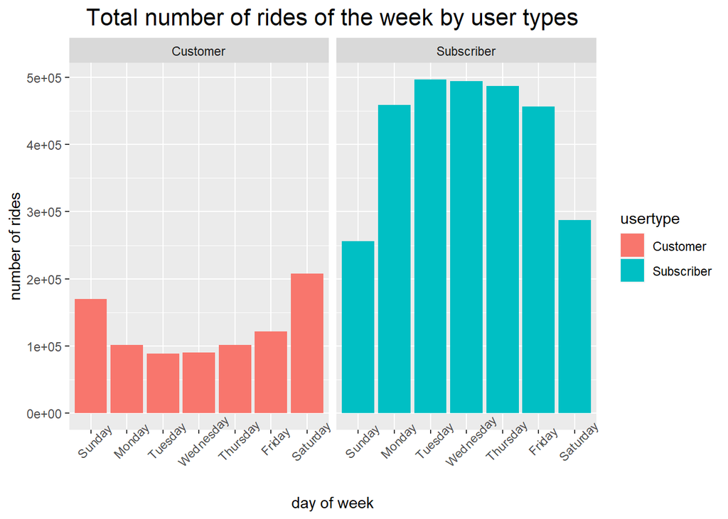

```r
ggplot(data= Divvy_Trips_2019)+
  geom_bar(mapping = aes(x=day_of_week, fill= usertype))+
  facet_wrap(~usertype)+
  labs(title = "Total number of rides of the week by user types", x= "day of week", y= "number of rides")+
  theme(plot.title = element_text(hjust = 0.5, size = 16),
        axis.text.x = element_text(angle = 45))
```

From the above graph we can see customer user type uses cyclistic bikes more on the weekends and less use on weekdays. On the other hand subscriber user type use cyclistic bikes more on weekdays and less use on weekends. Since members tend to use the bikes more on work days, these trends seem to support the assumption that a higher proportion of members use the bikes to commute to and from work.

### Total number of rides by months

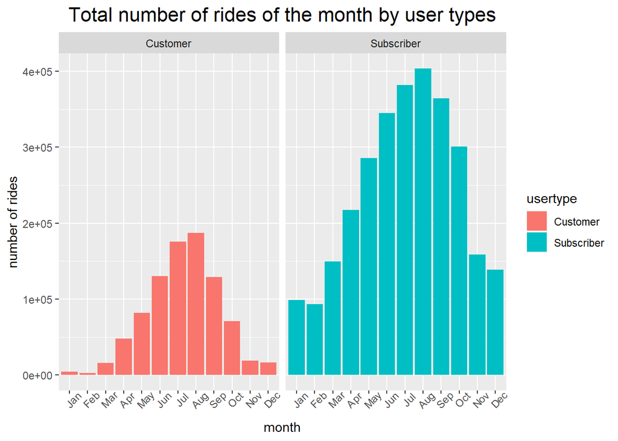

```r
ggplot(data = Divvy_Trips_2019)+
  geom_bar(mapping = aes(x= month, fill= usertype))+
  facet_wrap(~usertype)+
  labs(title = "Total number of rides of the month by user types", y= "number of rides")+
  theme(plot.title = element_text(hjust = 0.5, size = 16),
        axis.text.x = element_text(angle = 45))
```

From the above graph we can see both user type ride more bikes on summer season. When the fall season start both user types usage of the bikes starts to decline. On the winter season customer user types using cyclistic bikes drop more than 87% and subscriber user type usage of bikes drop more than 60%. When the start spring season starts both user type usage slowly start rising.

### Average trip duration of the weeks by user type

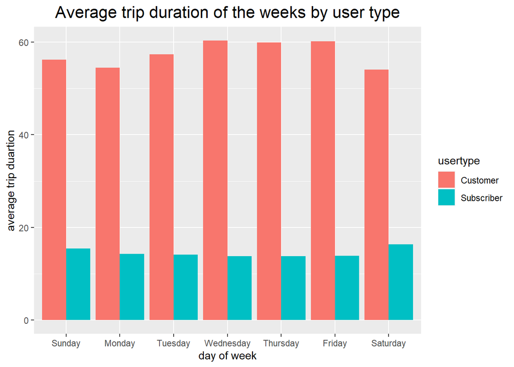

```r
Divvy_Trips_2019%>%
  group_by(usertype, day_of_week)%>%
  summarise(average_tripduration = mean(tripduration))%>%
  arrange(usertype, day_of_week)%>%
  ggplot(aes(x= day_of_week, y= average_tripduration, fill= usertype))+
  geom_col(position = "dodge")+
  labs(title = "Average trip duration of the weeks by user type", x= "day of week", y= "average trip duartion")+
  theme(plot.title = element_text(hjust = 0.5, size = 16))
```

From the above graph we can see that customer user type average trip duration is close to one hour all days of the week. On the other hand subscriber user type usage is on average 15 minutes. This shows that customer user type uses longer time.

### Averge trip duaration of the months by user type

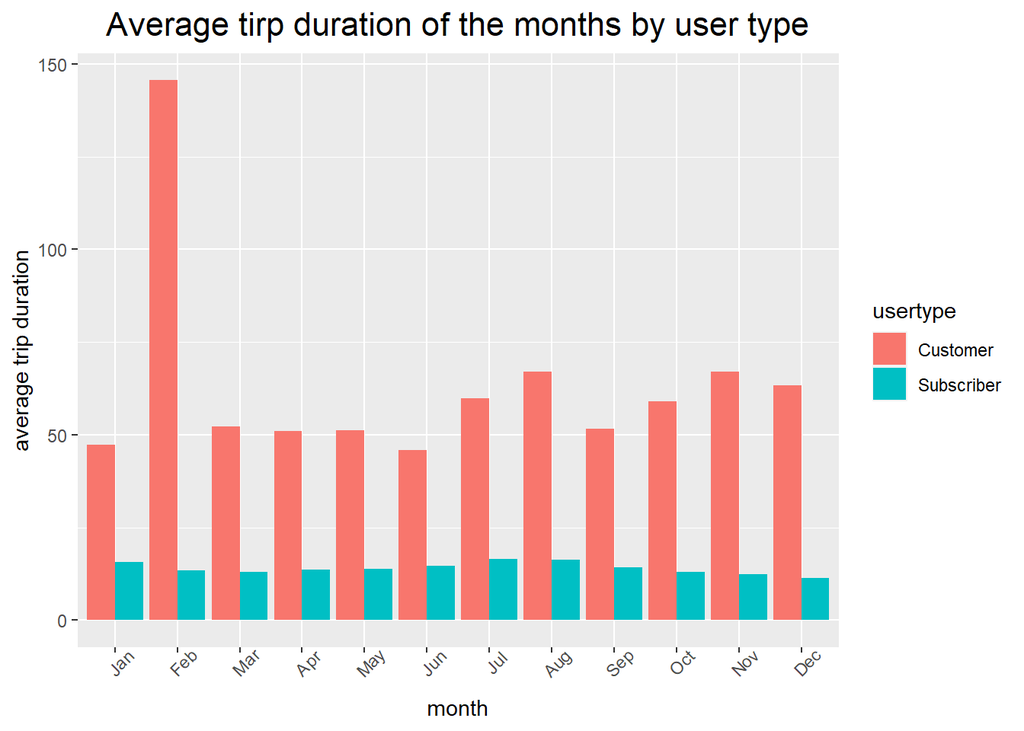

```r
Divvy_Trips_2019%>%
  group_by(usertype, month)%>%
  summarise(average_tripduration = mean(tripduration))%>%
  arrange(usertype, month)%>%
  ggplot(aes(x= month, y= average_tripduration, fill= usertype))+
  geom_col(position = "dodge")+
  labs(title = "Average tirp duration of the months by user type", y= "average trip duration")+
  theme(plot.title = element_text(hjust = 0.5, size = 16),
        axis.text.x = element_text(angle = 45))
```

### Rides by time of day

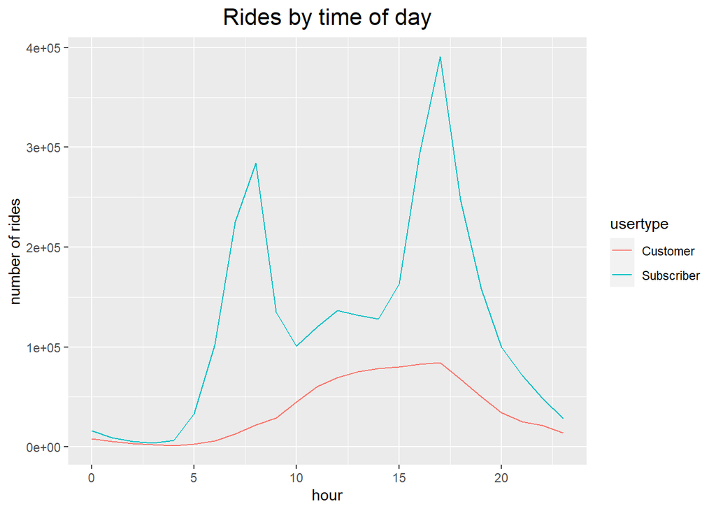

```r
Divvy_Trips_2019%>%
  group_by(hour, usertype)%>%
  summarise(n= n())%>%
  ggplot()+
  geom_line(aes(x= hour, y= n, color= usertype))+
  labs(title = "Rides by time of day", y= "number of rides")+
  theme(plot.title = element_text(hjust = 0.5, size = 16))
```

From the above chart we can see subscriber user type a spike usage of bikes from 6am to 8am in the morning and from 3pm to 5pm in the afternoon. Where as customer user type usage is smooth from 10am to 5pm.

## Act

Based on the cyclistic company trip data there are a total of 880,631 customer user type but the data didn’t have user identifier. so, the total customer user type didn’t refer to single users. I strongly recommend to give each users identifier number. Adding identifier to the data will benefit the company to know how many users the company have.

My top three recommendations are:-

1. Promote the cyclistic company on summer time because more of customer user type use the bikes on summer. Summer time will be more effective and can address more users. While promoting at summer time the promotions on weekends should be double because, the number of riders on the weekends are double comparing to weekdays. The campaign budget should be double for the weekends.
2. The customer user type rides on average 57minutes. When promoting subscription we need to clearly tell the customer user type how much money the can save for the long rides if they subscribe to cyclistic.
3. To get more engagement with customer user type the marketing campaign should target the top three starting and ending stations.